# Quantitative Methods – Day 1: Regression Basics

Harm H. Schuett

25 December, 2017

```r
# Imports
library(scatterplot3d)
library(igraph)
library(tibble)
darkblue <- rgb(0.2, 0.3, 0.4, 0.3)  # define a color for later use
```

# 1 What is a Regression?

> Linear regression is a method that summarizes how the average values of a numerical *outcome* variable vary over subpopulations defined by linear functions of *predictors*. (Gelman.2007, p. 31)

This is a very nice description of what a linear regression is, but it might be a bit technical sounding at first. Visualizing this might help:

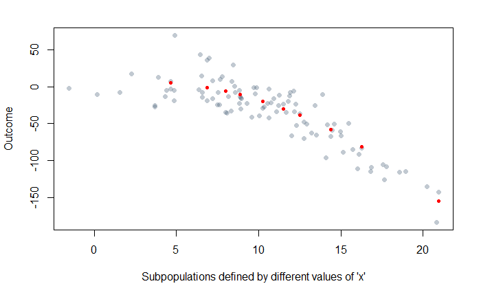

```r
set.seed(123)  # fix the random number generator
x <- rnorm(100, 10, 5)  # draw 100 numbers randomly from a normal distribution
y <- 2 + 3 * x - 0.5*x^2 + rnorm(100, 0, 20)  # create a new variable y as linear additive function of x
plot(x, y,  # plot x vs y (draws points by default)
     col=darkblue,  # color of the points
     pch=16,  # point character, 16 is a small dot
     xlab="Subpopulations defined by different values of 'x'",
     ylab="Outcome")
chosen_sub_population <- x[rank(x) %% 10 == 0]  # keep the 10th highest, 2th highest, etc. value
y_ticks <- 2 + 3 * chosen_sub_population - 0.5 * chosen_sub_population^2
points(chosen_sub_population, y_ticks, col="red", pch=20)  # adds the average y in red for evey ticks value
```

Think about the $x$ dimension as a continuum of groups. People/firms/observations with a low value of $x$ belong to a different group (sub-population) than observations with a high value of $x$. The regression function describes how the outcome $y$ changes “on average” as we move from one group to the next.

This becomes even more obvious with “categorical” $x$ rather than continuous $x$.

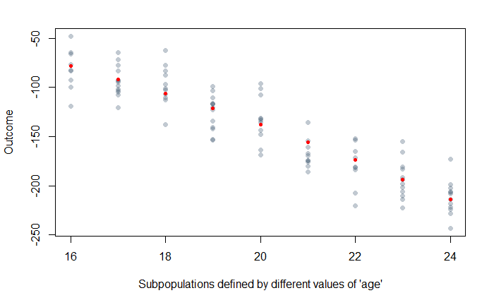

```r
set.seed(123)  # fix the random number generator
age_range <- 16:24
age <- sample(x=age_range, size=100, replace=TRUE)  # draw 100 integers randomly
y <- 2 + 3 * age - 0.5*age^2 + rnorm(100, 0, 20)  # create a new variable y as linear additive function of x
plot(age, y,  # plot x vs y (draws points by default)
     col=darkblue,  # color of the points
     pch=16,  # point character, 16 is a small dot
     xlab="Subpopulations defined by different values of 'age'",
     ylab="Outcome")
y_ticks <- 2 + 3 * age_range - 0.5 * age_range^2
points(age_range, y_ticks, col="red", pch=20)  # adds the average y in red for evey ticks value
```

But even if $x$ is continuous, the idea applies: a regression is way to describe how the average of an outcome changes going from one group of observations to another. It is a tool to reason about determinants of averages!

# 2 Conditional Expectations

> A substantial portion of research in econometric methodology can be interpreted as finding ways to estimate conditional expectations in the numerous settings that arise in economic applications. … we are interested in the effect of a variable $w$ on the expected value of $y$, holding fixed a vector of controls, $c$. The conditional expectation of interest is $E[y|w, c]$, which we will call a **structural conditional expectation.** (Wooldridge (2010), p. 13)

A conditional expectation is nothing more than the expected average $y$ given what you know about $x_i$ (or $w_i$ in Wooldridge (2010)), control variable(s) $c_i$, and what we know about the relation between all variables. This structural conditional expectation is essentially your theory – your assumed model of the links between $y$ and $x$ and $c$. It can be detailed – up to assuming a certain functional form and placing restrictions on the coefficients – or it can be rather vague. And as we will discuss in the latter parts of this course: That expectation can be uncertain to different degrees.

Let’s look at the simple *linear* example. Of course, there are also non-linear versions and generalized linear models. We will talk about them later. For now, let’s try to grasp the motivation behind the most common form: the simple linear regression.

$$y_i = a_0 + a_1 \times x_i + a_2 \times c_i + u_i$$

The regression $y_i = a_0 + a_1 \times x_i + a_2 \times c_i + u_i$ in fact has a structural conditional expectation at its core:

$$E[y|x, c] = a_0 + a_1 \times x + a_2 \times c$$

Or in pictures:

```r
set.seed(2345)  # fixing so that we always get the same numbers
x <- rnorm(100, 2, 1)
c <- rnorm(100, 3, 2)
u <- rnorm(100, 0, 20)
y <- 1 + 3 *x - 3 * c + u
par(mfrow=c(1,2))  # set graphics parameters. 1 row 2 columns
# 3d scatter plots. Drawing points
s3d <- scatterplot3d(x,c,y, pch=20, color=darkblue,
                     mar = c(3, 3, 2, 2), main="")
s3d <- scatterplot3d(x,c,y, pch=20, color=darkblue,
                     mar = c(3, 3, 2, 2), main="")
```

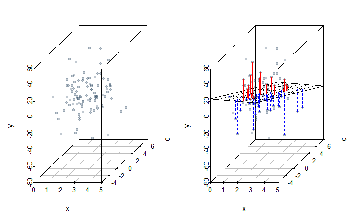

```r
# adding the regression plance
fit1 <- lm(y ~ x+c)  # fitting a regression model
# adding the regression plane to the second plot
s3d$plane3d(fit1, lty.box="solid", lty="dotted")
# computing difference between y and fitted plane
orig     <- s3d$xyz.convert(x, c, y)
plane    <- s3d$xyz.convert(x, c,  fitted(fit1))
# labeling whether lines needs to be drawn red or blue
i.negpos <- 1 + (resid(fit1) > 0) # 1 for neg 2 for pos
# drawing the lines
segments(orig$x, orig$y, plane$x, plane$y,
         col=c("blue", "red")[i.negpos],  # color
         lty=(2:1)[i.negpos]  # line type
         )
```

As you can see the “conditional expectation” is a regression plane. The plane gives you the average value of $y$ for a given combination of $x$ and $c$. Mind you, this is only the case because we created the data $y$ as a linear combination of $x$ and $c$. If say the true relationship is polynomial and we would fit a linear line through it, we would not be able to fit the average well. But, we would get the best linear predictor.

# 3 OLS and Conditional Expectation

## 3.1 The link between ols and conditional expectations

Let’s do some quick math to show that a regression indeed gives you the conditional expectation. And why we want to know that. The most common regressions are often also called the *minimum mean square linear predictor* or the *least squares linear predictor*. What can be shown quite easily is that the conditional expectation $CE$ is the minimum mean square predictor of $y$. (See Goldberger (1991))

Assume we want to predict $y$ with $x$. We need a good prediction function. Let’s say we want to minimize our prediction errors, or more specifically, our squared prediction errors:

$$\underset{m\in M}{\text{minimize}}\,\, E\left[(y_i - m(x_i))^2 \right]$$

$m$ is a prediction function. We don’t yet know, which one we want, other than that we want the one that minimizes the expected squared error from our predictions. $M$ is the set of all possible functions. This is a difficult optimization problem. But we do not need to solve it, we just need to check whether our candidate, the $CE = E[y|x]$ is the solution. Let’s expand the inner term with the $CE$:

$$\underset{m\in M}{\text{minimize}}\,\, E\left[\left(\left[y_i - E[y|x]\right] + \left[E[y|x] - m(x_i)\right]\right)^2 \right]$$

The inner part is a binomial formula. So:

$$\underset{m\in M}{\text{minimize}}\,\, E\left[ \left(y_i - E[y|x]\right)^2 + 2 \left(y_i - E[y|x]\right) \left(E[y|x] - m(x_i)\right) + \left(E[y|x] - m(x_i)\right)^2 \right]$$

The first of the three terms doesn’t depend on $m(x_i)$; so this term is irrelevant for the minimization. The second is zero per iterated expectations ($E\left[ \left(y_i - E[y|x]\right)\right] = E[y_i] - E[y_i]$).

So this is equivalent to solving

$$\underset{m\in M}{\text{minimize}}\,\, E\left[ \left(E[y|x] - m(x_i)\right)^2 \right]$$

Now, it is obvious that this term is minimized (set to zero) if $m(x_i)=E[y|x]$. So the conditional expectation function is what you should use if you want to minimize squared prediction errors. And the other way around as well. **If you are interested in the conditional expectation, minimizing mean squared prediction errors gets you there.**

## 3.2 Linear OLS as a useful approximation

How does simple linear ordinary least squares fit in? Suppose we want to limit ourselves to linear functions out of $M$:

$$\beta= \underset{b}{\text{argmin}}\,\, E\left[(y_i - x'b)^2 \right]$$

This is a bit easier. We can compute the first derivative and set it to zero to get the first order condition for a minimum or maximum:

$$2E\left[x\left(y_i - x'\beta \right)\right] = 0$$

Reshuffling on both sides of the equal sign gives you the OLS projection (*not the OLS estimator per se*):

$$\beta = E\left[xx'\right]^{-1} E\left[xy\right]$$

So the OLS projection is the minimum mean squared error linear predictor of $y$. By applying the same expansion trick as we did above we can also show that OLS is MMSE predictor of the $CE$ and also that both are equal if the $CE$ is indeed linear.

$$\beta= \underset{b}{\text{argmin}}\,\, E\left[(y_i - x'b)^2 \right] = E\left[(E[y|x] - x'b)^2 \right]$$

These are the reasons why OLS is so popular: It is the best linear approximation to an nearly always unknown $CE$. Why is that good? Because, in a way, it is a “conservative” approximation if you don’t know what the real $CE$ is. It has the least flexibility.

# 4 Interpreting Coefficients

What do we gain from approximating the $CE$? How are the coefficients to be interpreted?

```r
set.seed(123)
x <- rnorm(100, 10, 5)
y <- 2 + 3 * x + rnorm(100, 0, 9)
plot(x, y, col=darkblue, pch=16)
uni_reg <- lm(y~x)
betas <- coef(uni_reg)
abline(uni_reg)
```

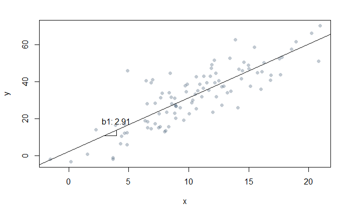

```r
x_pos <- 4
text(x_pos, betas[1] + betas[2] * x_pos + 5, labels=paste("b1:", round(betas[2], 2)))
triangle_x <- c(3, 4, 4)
triangle_y <- betas[1] + betas[2] * triangle_x
triangle_y[2] <- triangle_y[1]
lines(triangle_x, triangle_y)
```

For better visibility, here is the univariate case again. The coefficients represent the slope of the (often many-dimensional) linear projection. It tells you how the expected value of $y$ – the average $y$ you should expect – changes in units of $y$ with one additional unit of $x$.

But remember: A linear regression gives you the best linear predictor, which coincides with the conditional expectation only if the true data generating process in indeed linear.

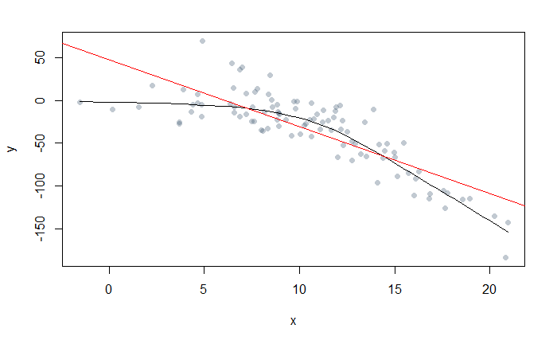

```r
set.seed(123)
x <- rnorm(100, 10, 5)
y <- 2 + 3 * x - 0.5*x^2 + rnorm(100, 0, 20)
scatter.smooth(x, y, col=darkblue, pch=16)
# plot(x, y, col=darkblue, pch=16)
abline(lm(y~x), col="red")
```

# 5 The multivariate case

*In the following cases we will use uppercase laters to denote Matrices, if a small cap letter does not have a subscript, consider it a vector*

Consider the model:

$$y = x_1 \beta_1 + x_2 \beta_2 + u$$

One of the great things (and terribly confusing things) about multivariate Regressions is that the coefficients can be interpreted as the average change in $y$ while holding other variables fixed. In the above equation $\beta_1$ is the average change in $y$ for a 1-unit change in $x_1$, holding $x_2$ constant. The same goes for $\beta_2$.

Let’s see this with an example:

```r
set.seed(1234)
x1 <- rnorm(100, 3, 10)
x2 <- 0.3 * x1 + rnorm(100, 1, 3)
y = 1 + 2 * x1 - 2 * x2 + rnorm(100, 0, 1)
summary(lm(y ~ x1))
```

```
Call:
lm(formula = y ~ x1)

Residuals:
     Min       1Q   Median       3Q      Max
-17.0501  -3.8176  -0.4303   3.5982  17.3140

Coefficients:
            Estimate Std. Error t value Pr(>|t|)
(Intercept) -1.12648    0.62688  -1.797   0.0754 .
x1           1.42347    0.06209  22.925   <2e-16 ***
---
Signif. codes:  0 ‘***’ 0.001 ‘**’ 0.01 ‘*’ 0.05 ‘.’ 0.1 ‘ ’ 1

Residual standard error: 6.205 on 98 degrees of freedom
Multiple R-squared:  0.8428,    Adjusted R-squared:  0.8412
F-statistic: 525.6 on 1 and 98 DF,  p-value: < 2.2e-16
```

```r
summary(lm(y ~ x1 + x2))
```

```
Call:
lm(formula = y ~ x1 + x2)

Residuals:
    Min      1Q  Median      3Q     Max
-3.1933 -0.6734  0.1060  0.5823  2.7650

Coefficients:
            Estimate Std. Error t value Pr(>|t|)
(Intercept)  1.10999    0.10348   10.73   <2e-16 ***
x1           1.99922    0.01327  150.67   <2e-16 ***
x2          -1.97056    0.03124  -63.07   <2e-16 ***
---
Signif. codes:  0 ‘***’ 0.001 ‘**’ 0.01 ‘*’ 0.05 ‘.’ 0.1 ‘ ’ 1

Residual standard error: 0.9624 on 97 degrees of freedom
Multiple R-squared:  0.9963,    Adjusted R-squared:  0.9962
F-statistic: 1.291e+04 on 2 and 97 DF,  p-value: < 2.2e-16
```

First, think a bit about why we get different results for $x_1$ in these two cases.

The mathematical proof for why we we get this result is the **Frisch-Waugh-Lovell Theorem**.

For the theorem, we first need to introduce a certain way of presenting residuals, called the *residual maker matrix* $M = I - X(X'X)^{-1}X'$: It is called the residual maker because if you left-multiply it to a vector, you get the residual vector:

$$My = (I - X(X'X)^{-1}X')y = y - X(X'X)^{-1}X'y = y - X\beta = u$$
Multiplying $M$ on the left with $y$ yields the residual $u$. We need this matrix for the following proof:

Consider again: $y = X_1 \beta_1 + X_2 \beta_2 + u$. We are interested in the interpretation of $\beta_2$, which is the effect of $X_2$ on $y$ holding $X_1$ constant. In a way we could take out the relation of $X_1$ with both $y$ and $X_2$ and regress what is left of $y$ and $X_2$. We can use the residual maker matrix for that $\tilde{y}=M_1y$ and $\tilde{X}_2=M_1X_2$ are the residuals after taking out the linear relation with $X_1$. Then regress $\tilde{y}$ on $\tilde{X}_2$

$$\tilde{y} = \tilde{X}_2a_2 + u_2$$

Now, this is a regression of $y$, after taking out the relation with $X_1$, on $X_2$, after taking out its relation with $X_1$. The first part of the FWL Theorem shows that $a_2 = \beta_2$, supporting the partialling out interpretation of $\beta_2$. The second part (which we won’t look at) shows that you also get the same standard errors.

Let’s look at $a_2$:

$$\begin{align}
a_2 &= (\tilde{X}_2'\tilde{X}_2)^{-1}\tilde{X}_2'\tilde{y}\\
& = (X_2'M_1'M_1X_2)^{-1}X_2'M_1'M_1y\\
& = (X_2'M_1X_2)^{-1}X_2'M_1y\\
& = (X_2'M_1X_2)^{-1}X_2'M_1(X_1\beta_1 + x_2\beta_2 + \hat{u})\\
& = (X_2'M_1X_2)^{-1}(X_2'M_1X_1\beta_1 + X_2'M_1X_2\beta_2 + X_2'M_1\hat{u})
\end{align}$$

There are a few things that help here, which I won’t prove: $M_1'M_1=M_1$, $M_1X=0$, $M_1\hat{u}=\hat{u}$, and $X_2\hat{u}=0$. That means, the above equation simplifies, because the first and last term in the bracket are zero:

$$a_2 = (X_2'M_1X_2)^{-1}(X_2'M_1X_2\beta_2) = \beta_2$$

So, $a_2$ from a short regression of $\tilde{y}$ on $\tilde{X}_2$ is the same as the $\beta_2$ of the long regression. Therefore, you can interpret $\beta_2$ as the relation between $y$ and $X_2$ after $X_1$ has been controlled for. And “controlled for” means taking out the relation of $X_1$ out of *both* $y$ and $X_2$. So, in the last simulated regression above, $y_i = 1 + 2x_1 - 2x_2 + u$ and $x_2 = 0.3x_1 + e$.

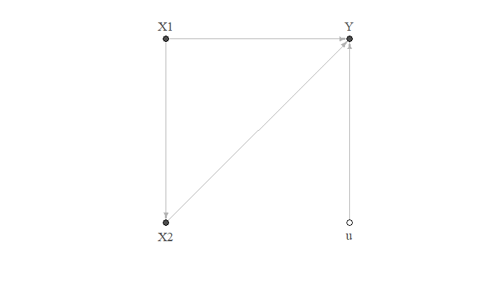

```r
Nodes <- tribble(
  ~nodes, ~x, ~y,
  "Y",     1,  1,
  "X1",    0,  1,
  "X2",    0,  0,
  "u",     1,  0)
Edges <- tribble(
  ~from,  ~to,
  "X1",    "Y",
  "X1",    "X2",
  "X2",    "Y",
  "u",     "Y")
plot(graph_from_data_frame(vertices=Nodes, d=Edges, directed=TRUE),
     vertex.color=c(rep("gray30", nrow(Nodes)-1), "white"),
     vertex.size=7,
     label.font=2, vertex.size=30, vertex.label.cex=1.2,
     edge.arrow.size=0.5, edge.color="gray70",
     vertex.label.color="gray30", vertex.label.dist=2,
     vertex.label.degree=c(-pi/2, -pi/2, pi/2, pi/2))
```

So, $x_1$ and $x_2$ are related. If we simply regress $y = \hat{a}_0 + \hat{a}_1x_1 + \hat{u}$, we get $a_1=1.4$. Why? Because $x_1$ has an additional effect on $y$ via $x_2$; since $x_2$ has a negative effect on $y$, the overall effect is less than 2. But, if we regress $y = \hat{b}_0 + \hat{b}_1x_1 + \hat{b}_2x_2 + \hat{u}$, we get $b_1 = 2.00$ and $b_2 = -1.97$. Why, because if we take out the effect of $x_2$ on $y$, the additional channel of $x_1$ via $x_2$ is blocked. (We do not have to take out anything out of $x_1$, because $x_2$ does not affect $x_1$.)

As a word of caution:

> The problem is that regression is like a demon or djinn from folktale. It answers exactly that question that you asked it. Often you don’t realize though that you asked the wrong question ~ paraphrasing Richard McElreath

We will talk about the pitfalls of interpreting coefficients tomorrow.

# 6 Excercises

1. What would happen in the last example (the one tied to the last arrow graph) if you regress $y$ on $x_2$ only? Explain why? Then run the regression.
2. Use the idea of Frisch-Waugh-Lovell Theorem to simulate and see whether you get the same coefficients either from regressing residuals or multivariate regressions.

# 7 References

Goldberger, Arthur Stanley. 1991. *A Course in Econometrics*. Harvard University Press.

Wooldridge, Jeffrey M. 2010. *Econometric Analysis of Cross Section and Panel Data*. MIT Press.